# Stat5405 Homework 4

Author

Giovanni Lunetta

Published

September 27, 2023

## Due: Sun. Oct. 1 2023 at 11:59 pm - submit on HuskyCT

### NOTE THAT FOR ALL TESTS OF SIGNFICANCE $\alpha = 0.05$ UNLESS OTHERWISE STATED.

**Q1. (5 points).** Interpret this statement in your own words using a criterion you have studied: *The one-factor ANOVA $F$-stat is very small, so that the chance of getting an $F$-statistic value which is as small or smaller than the $F$-stat obtained from the observed data is only $0.00004$.*

Interpretation:

The small value of the one-factor ANOVA F-statistic suggests that there is little variability between the group means compared to the variability within the groups. The probability of obtaining an F-statistic as small or smaller than the observed one is extremely low (0.00004), indicating that the null hypothesis (that all group means are equal) is very likely to be false.

**Q2. (45 points).** Consider the dataset tensile from the R package *ACSWR*. You looked at the one-factor ANOVA $F$-test in HW3. Now, use suitable R functions to answer these questions.

```r
library(ACSWR)
data(tensile)
str(tensile)
```

```
'data.frame':   25 obs. of  4 variables:
 $ Test_Sequence   : int  1 2 3 4 5 6 7 8 9 10 ...
 $ Run_Number      : int  8 18 10 23 17 5 14 6 15 20 ...
 $ CWP             : int  20 30 20 35 30 15 25 20 25 30 ...
 $ Tensile_Strength: int  12 19 17 7 25 7 14 12 18 22 ...
```

1. Obtain solutions of the effects of the levels of *CWP* in the one-factor ANOVA model you fit for the response.

Null Hypothesis: The mean tensile strength is the same for all levels of CWP.

$H_0$: $\mu_1 = \mu_2 = \mu_3 = \mu_4 = \mu_5$

where $\mu_i$ is the mean tensile strength for level $i$ of CWP.

Alternative Hypothesis: The mean tensile strength is different for at least one level of CWP.

$H_a$: $\mu_i \neq \mu_j$ for at least one pair of levels $i$ and $j$ of CWP.

$\alpha = 0.05$

Assumptions (WILL BE VALIDATED AFTER RUNNING ANOVA MODEL):

Normality:

We assume that the tensile strength for each level of CWP is normally distributed.

Independence:

We assume that the tensile strength for each level of CWP is independent of the tensile strength for the other levels of CWP.

Equal Variance:

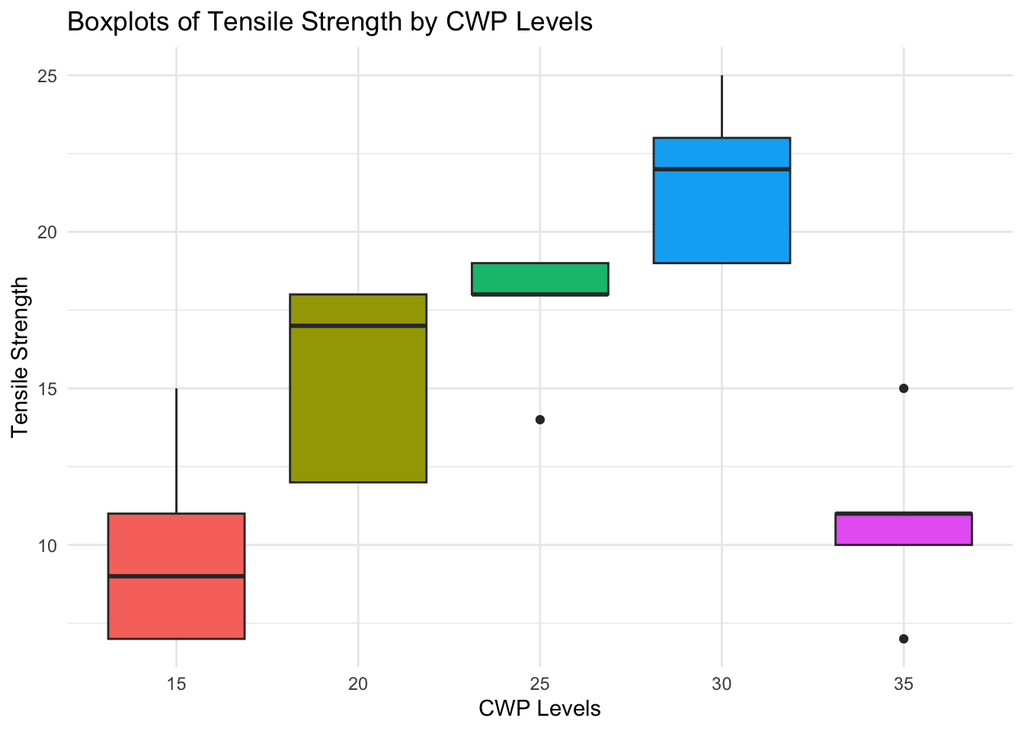

```r
library(gridExtra)
library(ggplot2)

# Create boxplots by CWP levels using ggplot
ggplot(tensile, aes(x=as.factor(CWP), y=Tensile_Strength, fill=as.factor(CWP))) +
    geom_boxplot(show.legend = FALSE) +
    labs(x="CWP Levels", y="Tensile Strength") +
    theme_minimal() +
    ggtitle("Boxplots of Tensile Strength by CWP Levels")
```

We assume that the variance of the tensile strength for each level of CWP is equal.

```r
# Fit a one-factor ANOVA model
anova_model <- aov(Tensile_Strength ~ as.factor(CWP), data = tensile)
summary(anova_model)
```

```
               Df Sum Sq Mean Sq F value   Pr(>F)
as.factor(CWP)  4  475.8  118.94   14.76 9.13e-06 ***
Residuals      20  161.2    8.06
---
Signif. codes:  0 '***' 0.001 '**' 0.01 '*' 0.05 '.' 0.1 ' ' 1
```

Validate Assumptions:

Normality:

Null Hypothesis: The residuals $e_{ij}$ are normally distributed.

$H_0$: $e_{ij} \sim N(0, \sigma^2)$

where $e_{ij}$ is the residual for the $j$th observation in the $i$th level of CWP.

Alternative Hypothesis: The residuals $e_{ij}$ are not normally distributed.

$H_a$: $e_{ij} \nsim N(0, \sigma^2)$

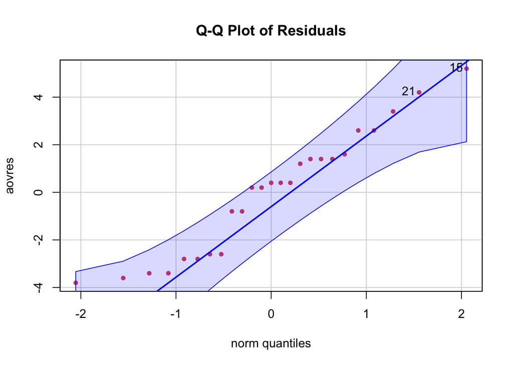

```
[1] 15 21
```

```r
library(car)
aovfits <- fitted(anova_model)
aovres <- residuals(anova_model)
car::qqPlot(aovres, main = "Q-Q Plot of Residuals", pch = 19, col = 2, cex = 0.7)
```

```r
shapiro.test(aovres)
```

```
    Shapiro-Wilk normality test

data:  aovres
W = 0.94387, p-value = 0.1818
```

The large $p$-value (much greater than 0.05) from the Shapiro-Wilk significance test for normality of $e_{ij}$ validates the normality assumption.

Equal Variance:

Null Hypothesis: The variance of the tensile strength for each level of CWP is equal.

$H_0$: $\sigma_1^2 = \sigma_2^2 = \sigma_3^2 = \sigma_4^2 = \sigma_5^2$

where $\sigma_i^2$ is the variance of the tensile strength for level $i$ of CWP.